# Oncor Electicity Delivery Project

Ives

4/3/2020

Recent studies showed that Electric Vehicles(EV) charging has a large impact on electricity delivery especially when many users charge EV simultaneously. Therefore, EV charging monitoring has become a more important and urgent missing piece in electricity delivery.This project is aimed to identify which electricity users have Electric Vehicles (EV) based on electricity meter data of 6 million records.

## 1. Introduction to data and data preprocessing

```r
#load
data <- read.csv("C:/Study/Capstone/Data/EV_Team_Sample_5.csv")
#change the colom name
colnames(data)[1]="id"
#process null values
data[which(is.na(data$consumption)),3] <- 0
#change the type of time
data$read_date <- as_datetime(data$read_date)
#slice the data
d1 <- data
#extract all the years and months
d1 <- d1 %>%
  mutate(year=year(d1$read_date),month=month(d1$read_date))
#get the time metrix
y_m=d1%>%
  select(year,month)%>%
  distinct()
#show the data
str(data)
```

```
## 'data.frame':    6313866 obs. of  3 variables:
##  $ id         : Factor w/ 100 levels "RDM0077172","RDM0112455",..: 1 1 1 1 1 1 1 1 1 1 ...
##  $ read_date  : POSIXct, format: "2018-04-01 00:00:00" "2018-04-01 00:15:00" ...
##  $ consumption: num  0.942 0.538 0.588 0.542 1.254 ...
```

- We have 3 coloums but 6 million observations.
  - The id is the only key to identify each user anonymously.In this training dataset, we have 100 users.
  - The read_date means when the data was collected. This dataset contains 2 years data collected by every 15 minute
  - The consumption is the electricity usage of every 15 mintues by the unit of KWh. We will transfer it to average electricity power for furthur analysis.

## 2. Non-Intrusive Load Monitoring(NILM) model

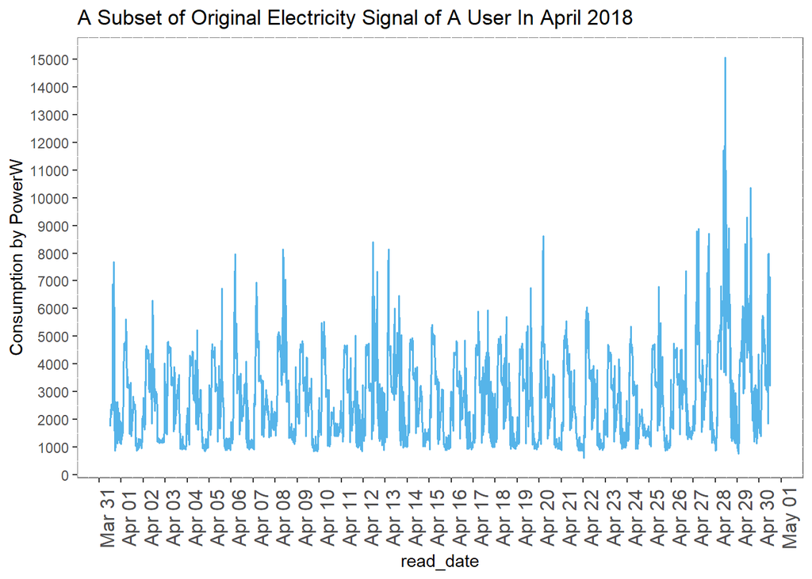

```r
#select a dataset
power_data=subset(d1,d1$id=='RDM2377306'&d1$year==2018&d1$month==4)
#show it in a graph
ggplot(power_data[1:3000,],aes(x=read_date,y=consumption*4000,group=1)) %>%
  +geom_line(color="#56B4E9",size=0.7) %>%
  +scale_x_datetime(date_labels = "%b %d",breaks=("24 hours"))%>%
  +scale_y_continuous(breaks=seq(0,18000,1000)) %>%
  +theme(axis.text.x = element_text(angle=90, size=12)) %>%
  +ylab("Consumption by PowerW")%>%
  +theme(panel.background = element_rect(fill = "white", colour = "grey50")) %>%
  +ggtitle("A Subset of Original Electricity Signal of A User In April 2018")
```

We can see there are many peaks which indicate tense electricity usage probably caused by AC,evener and EV.This NILM model will identify these peaks to filter all the other useless information for furthur detecting.

### STEP 1 Get the residual and remove it

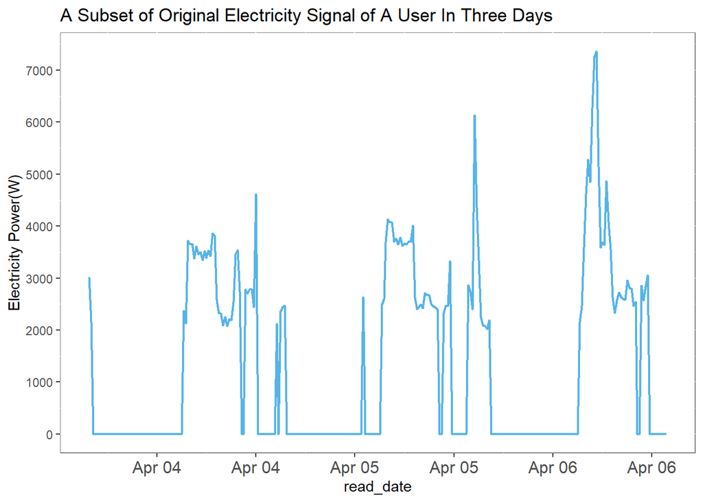

```r
# the first column should be time and the second column should be the power data
org_time=power_data$read_date
orgAgg=power_data$consumption*4000
# the first column should be time and the second column should be the power data
org_time=power_data$read_date
orgAgg=power_data$consumption*4000
res=min(orgAgg)
ts=orgAgg-res
#set threshold value
Threshold=Threshold_value
EVsignal = ts;
EVsignal[EVsignal<Threshold]=0

#draw a graphic
power_data$consumption=EVsignal
#show it in a graph
ggplot(power_data[300:580,],aes(x=read_date,y=consumption,group=1)) %>%
  +geom_line(color="#56B4E9",size=0.71) %>%
  +scale_x_datetime(date_labels = "%b %d",breaks=("12 hours"))%>%
  +scale_y_continuous(breaks=seq(0,18000,1000)) %>%
  +theme(axis.text.x = element_text(angle=0, size=12)) %>%
  +ylab("Electricity Power(W)")%>%
  +theme(panel.background = element_rect(fill = "white", colour = "grey50")) %>%
    +ggtitle("A Subset of Original Electricity Signal of A User In Three Days")
```

### STEP 2 Get segments

From last step, we have the peaks data and right now we need to know the start point and end point of these peaks to analyze. So I define a function getSegment() to finish this task.

```r
# Define getSegment function, return segment
## the first row is N/A, if there is no segment, there will only be one row
getSegment <- function(EVsignal){
  idx=as.numeric(EVsignal>0)
  idx2=c(0,idx,0)
  prePt = c("")
  postPt = c("")

  #get the segment starts and ends
  for (i in 2:length(idx)){
    if (idx2[i-1] == 0 & idx2[i] == 1 & idx2[i+1] == 1){
      prePt=c(prePt,i-1)
    }
    if (idx2[i-1] == 1 & idx2[i] == 1 & idx2[i+1] == 0){
      postPt=c(postPt,i-1)
    }
  }
  #if the segment extend this month signal, we set the last index as the postPt
  if(length(prePt)==length(postPt)+1){
    postPt=c(postPt,length(idx))
  }
  segment=tibble(prePt,postPt)
  return (segment)
}

segment=getSegment(EVsignal)
segment <- as.data.frame(lapply(segment, function(x) as.numeric(as.character(x))))
```

In this sample dataset, our peaks are showed below:

Table with peaks

|  | prePt | postPt |
| --- | --- | --- |
| 10 | 239 | 242 |
| 11 | 250 | 277 |
| 12 | 280 | 283 |
| 13 | 291 | 301 |
| 14 | 346 | 373 |
| 15 | 376 | 381 |

### Step 4 Filter segments based on charging duration

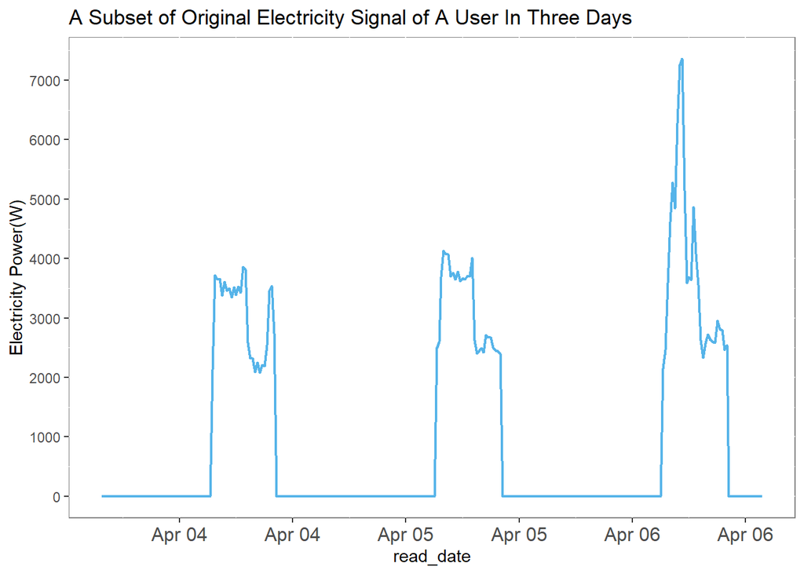

```r
#set duration range
min_Duration = min_duration
max_Duration = max_duration

#calculate the duraton
segment= segment %>% mutate(duration=interval*(postPt-prePt))
#filter segments
Dur_segment = filter(segment,duration>min_duration&duration<max_duration)

#draw a graphic
EVsignal[300:346]=0
EVsignal[374:441]=0
EVsignal[470:537]=0
EVsignal[566:580]=0
power_data$consumption=EVsignal
#show it in a graph
ggplot(power_data[300:580,],aes(x=read_date,y=consumption,group=1)) %>%
  +geom_line(color="#56B4E9",size=0.71) %>%
  +scale_x_datetime(date_labels = "%b %d",breaks=("12 hours"))%>%
  +scale_y_continuous(breaks=seq(0,18000,1000)) %>%
  +theme(axis.text.x = element_text(angle=0, size=12)) %>%
  +ylab("Electricity Power(W)")%>%
  +theme(panel.background = element_rect(fill = "white", colour = "grey50")) %>%
    +ggtitle("A Subset of Original Electricity Signal of A User In Three Days")
```

We have three peaks left after filtering by duration.

### STEP 5 Calculate the height and the width of each peaks

The height means the electric power of a peak and the width means duration time. These two features are very useful for EV signals to be distinguished from AC’s and evener’s.

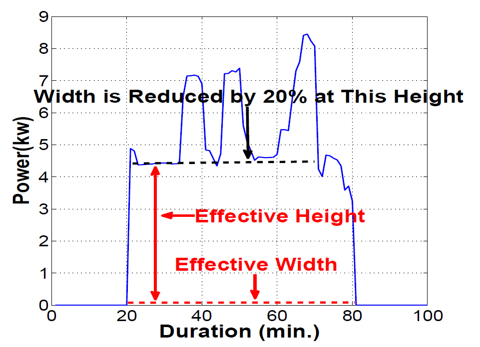

In this NILM model, the effective width is defined as the width of a segment at bottom. The effective height is defined as the height at which the segment’s width becomes only 80% of the bottom width.

```r
#Define getHeight function
calHeight = function(signal,width_percent){
  for (i in 1:300){
    height=i/300*max(signal)
    if (sum(as.numeric(signal>=height))/length(signal)<width_percent){
      return(height)
    }
  }
}
getHeight = function(segment,signal){
  height=c()
  for (i in 1:nrow(segment)){
    height=c(height,calHeight(signal[segment[i,1]:segment[i,2]],width_percent))
  }
  return(mutate(segment,estPower=height))
}

Height_segment=getHeight(Dur_segment,EVsignal)

#Filter segment which height is below EVAMP
EV_segment=Height_segment %>% filter(estPower>3000)
EV_segment
```

```
##   prePt postPt duration estPower
## 1  1152   1165      195 3431.280
## 2  1978   2005      405 3157.867
## 3  2074   2101      405 3018.987
## 4  2650   2708      870 4245.120
## 5  2746   2800      810 3517.920
```

Therefore, this results shows that this user might charge his/her EV 5 times a month. So, this is the process we did to one subdataset. In my real project, I combined all these steps into a function file and the next step is to apply this model to all the 2400 subdatasets.

## 5.Apply NILM Model to all the subdatasets

```r
#Group the data by year and month and then get the result
result=group_by(d1,id,year,month)%>% do(as.data.frame(estEV(.)))

#remove na in variance
result$Duration.Variance[is.na(result$Duration.Variance)]=0
result$estPower.Variance[is.na(result$estPower.Variance)]=0

#make the last month for every user to be 0
for(i in 2:nrow(result)){
  if(result[i,1]!=result[i-1,1]){
    result[i,4]=0
  }
}

##Calculate the longest time of continuent signal
library(data.table)
result=as.data.table(result)[, maxperiod := sequence(.N), by = rleid(EV_user_flag)][EV_user_flag == "0", maxperiod := 0][]

#build a new table for selecting
r1=group_by(result,id)%>%summarise(total_month=sum(EV_user_flag),
                                   data_period=n(),
                                   mean_times=mean(Number.of.Signal),
                                   sd_times=sd(Number.of.Signal),
                                   maxperiod=max(maxperiod),
                                   mean_dur_var=mean(Duration.Variance),
                                   mean_estP_mean=mean(mean.estPower),
                                   mean_estP_var=mean(estPower.Variance))
r2=r1[order(r1$maxperiod,decreasing = TRUE),]
print(r2)
```

```
## # A tibble: 100 x 9
##    id    total_month data_period mean_times sd_times maxperiod mean_dur_var
##    <fct>       <dbl>       <int>      <dbl>    <dbl>     <int>        <dbl>
##  1 RDM2~          23          24       9.67     4.56        23        145.
##  2 RDM2~          23          24       4.5      2.92        23        132.
##  3 RDM9~          22          24       4.88     2.95        22         93.8
##  4 RDM0~          21          24       4.92     3.44        17         72.1
##  5 RDM9~          21          24       5.08     3.40        16        115.
##  6 RDM4~          22          24      19.6     10.2         15        160.
##  7 RDM0~          14          15       4.87     2.00        14         35.5
##  8 RDM2~          21          24      13       10.5         12         89.7
##  9 RDM0~          22          24       5.5      4.32        11         88.8
## 10 RDM2~          18          24       7.12     8.10        11         87.5
## # ... with 90 more rows, and 2 more variables: mean_estP_mean <dbl>,
## #   mean_estP_var <dbl>
```

```r
final_result=r2[which(r2$total_month/r2$data_period>=0.5
                     &r2$maxperiod/r2$total_month>=0.6
                     &r2$mean_times>1
                     &r2$mean_times<15
                     &r2$sd_times<10
                     &r2$mean_estP_mean>2800),]
final_result
```

```
## # A tibble: 8 x 9
##   id    total_month data_period mean_times sd_times maxperiod mean_dur_var
##   <fct>       <dbl>       <int>      <dbl>    <dbl>     <int>        <dbl>
## 1 RDM2~          23          24       9.67     4.56        23        145.
## 2 RDM2~          23          24       4.5      2.92        23        132.
## 3 RDM9~          22          24       4.88     2.95        22         93.8
## 4 RDM0~          21          24       4.92     3.44        17         72.1
## 5 RDM9~          21          24       5.08     3.40        16        115.
## 6 RDM0~          14          15       4.87     2.00        14         35.5
## 7 RDM2~          18          24       7.12     8.10        11         87.5
## 8 RDM3~          15          24       5.46     6.14         9        116.
## # ... with 2 more variables: mean_estP_mean <dbl>, mean_estP_var <dbl>
```